# R Notebook

```r
# install.packages("sjPlot")
#install.packages("relaimpo") ## relative importance
library(readxl)
library(tidyverse)
library(sjPlot)
library(relaimpo)
```

```r
gosp <- read_excel("../data-raw/gospodarstwa.xlsx")
gosp$l_osob <- round(gosp$los)
gosp
```

| klm | woj | trb | zut | d21 | d32 | d345 | d347 | d348 | d36 | d38 | d61 | d63 | los | dochg | wydg | l_osob |
| --- | --- | --- | --- | --- | --- | --- | --- | --- | --- | --- | --- | --- | --- | --- | --- | --- |
| 1 | 02 | 11 | 5 | 2 | 1 | 1 | 2 | 1 | 69 | 2 | 3 | 3 | 1.00 | 1191.41 | 1037.29 | 1 |
| 1 | 02 | 6 | 1 | 2 | 1 | 2 | 2 | 1 | 74 | 3 | 4 | 2 | 2.00 | 821.00 | 887.01 | 2 |
| 1 | 02 | 3 | 1 | 1 | 3 | 1 | 2 | 1 | 83 | 3 | 4 | 1 | 4.00 | 6669.87 | 6792.13 | 4 |
| 1 | 02 | 12 | 5 | 2 | 1 | 3 | 3 | 2 | 44 | 2 | 4 | 1 | 3.00 | 1872.59 | 1806.83 | 3 |
| 1 | 02 | 1 | 5 | 1 | 3 | 1 | 2 | 1 | 110 | 5 | 4 | 2 | 2.00 | 1731.44 | 2795.08 | 2 |
| 1 | 02 | 12 | 1 | 1 | 1 | 2 | 3 | 1 | 36 | 1 | 3 | 3 | 4.00 | 2200.00 | 2359.31 | 4 |
| 1 | 02 | 12 | 1 | 1 | 1 | 1 | 1 | 1 | 59 | 2 | 3 | 3 | 5.00 | 3600.55 | 6274.59 | 5 |
| 1 | 02 | 12 | 5 | 1 | 1 | 2 | 2 | 1 | 32 | 2 | 3 | 3 | 6.00 | 1938.40 | 1237.12 | 6 |
| 1 | 02 | 12 | 5 | 1 | 1 | 1 | 2 | 1 | 63 | 3 | 3 | 2 | 2.00 | 2532.00 | 2703.61 | 2 |
| 1 | 02 | 8 | 1 | 2 | 1 | 2 | 3 | 1 | 46 | 2 | 4 | 2 | 5.00 | 2368.46 | 1835.71 | 5 |

[output cut: 990 more lines]

Budujemy model, w którym chcemy wyjaśnić poziom wydatków liczbą osób w gospodarstwie domowym

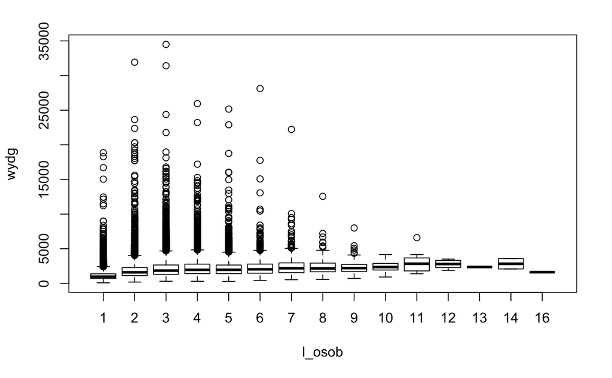

```r
boxplot(formula = wydg ~ l_osob, data = gosp)
```

wydatki ~ liczba osób

Aby oszacować model regresji linowej w R należy zastosowac funkcję lm (linear model)

zmienna objaśniana ~ zmienna objaśniająca 1 + zmienna objaśniająca 2 + zmienna objaśniająca 3 + …

```r
model1 <- lm(formula = wydg ~ los, data = gosp)
model1
```

```
Call:
lm(formula = wydg ~ los, data = gosp)

Coefficients:
(Intercept)          los
     1395.6        201.3
```

```r
summary(model1)
```

```
Call:
lm(formula = wydg ~ los, data = gosp)

Residuals:
   Min     1Q Median     3Q    Max
 -3006   -818   -341    383  32494

Coefficients:
            Estimate Std. Error t value Pr(>|t|)
(Intercept) 1395.618     18.026   77.42   <2e-16 ***
los          201.270      5.234   38.45   <2e-16 ***
---
Signif. codes:  0 ‘***’ 0.001 ‘**’ 0.01 ‘*’ 0.05 ‘.’ 0.1 ‘ ’ 1

Residual standard error: 1479 on 32449 degrees of freedom
  (36 observations deleted due to missingness)
Multiple R-squared:  0.04358,   Adjusted R-squared:  0.04355
F-statistic:  1479 on 1 and 32449 DF,  p-value: < 2.2e-16
```

$$wydg = 1395.618 + 201.270 \times los$$

- `Residuals` – to są reszy czyli `y - \hat{y}`, `\hat{y}` to są wartości z modelu.
- `Coefficients` – oszacowania parametrów (bet) z modelu wraz z błędami standardowymi
- `Estimate` to oszacowania bet z modelu
- `Std. Error` to błąd standardowy bet z modelu
- `t value` – statystyka t-studenta `Estimate` / `Std. Error`

Badamy następujący układ hipotez

$$H_0: \beta_k = 0, \quad H_1: \beta_k \neq 0$$
+ `Pr(>|t|)` – wartość p (p-value) + `Residual standard error` – oszacowanie błędu standardowego składnika losowego

Względny błąd szacunku = oszacowanie błędu standardowego składnika losowego (`sigma`) do przeciętnej wartości naszego y (`wydg`) (wartość jest w %)

```r
sigma(model1) / mean(gosp$wydg, na.rm=T)
```

```
[1] 0.7346722
```

- `F-statistic`, która służy do testowania układu hipotez w postaci

$$H_0: \mathbf{\beta} = \mathbf{0}, \quad H_1: \mathbf{\beta} \neq \mathbf{0}$$

Dodajemy do modelu zmienną jakościową czyli mierzoną na skali porządkowej lub nominalnej

```r
gosp$miejsce <- factor(x = gosp$klm,
                       levels = 1:6,
                       labels = c("pow 500T", "200T-500T", "100T-200T", "20T-100T", "pon. 20T", "wies"))
```

Funkcja update pozwala na aktualizację konkretnego modelu

```r
## model2 <- lm(formula = wydg ~ los + miejsce, data = gosp)

model2 <- update(object = model1,  formula = . ~ . + miejsce)
summary(model2)
```

```
Call:
lm(formula = wydg ~ los + miejsce, data = gosp)

Residuals:
   Min     1Q Median     3Q    Max
 -4251   -771   -309    375  31850

Coefficients:
                 Estimate Std. Error t value Pr(>|t|)
(Intercept)      1901.568     25.236   75.35   <2e-16 ***
los               247.495      5.279   46.88   <2e-16 ***
miejsce200T-500T -439.753     31.896  -13.79   <2e-16 ***
miejsce100T-200T -592.345     34.162  -17.34   <2e-16 ***
miejsce20T-100T  -631.877     28.140  -22.45   <2e-16 ***
miejscepon. 20T  -750.717     30.961  -24.25   <2e-16 ***
miejscewies      -982.607     26.151  -37.57   <2e-16 ***
---
Signif. codes:  0 ‘***’ 0.001 ‘**’ 0.01 ‘*’ 0.05 ‘.’ 0.1 ‘ ’ 1

Residual standard error: 1446 on 32444 degrees of freedom
  (36 observations deleted due to missingness)
Multiple R-squared:  0.08614,   Adjusted R-squared:  0.08597
F-statistic: 509.7 on 6 and 32444 DF,  p-value: < 2.2e-16
```

Dołączymy do modelu zmienną trb – typ rodziny biologicznej

```r
model3 <- update(object = model2, formula = . ~ . + factor(trb))
summary(model3)
```

```
Call:
lm(formula = wydg ~ los + miejsce + factor(trb), data = gosp)

Residuals:
   Min     1Q Median     3Q    Max
 -2853   -749   -276    356  31805

Coefficients:
                 Estimate Std. Error t value Pr(>|t|)
(Intercept)       2338.81      33.26  70.328  < 2e-16 ***
los                174.51      10.37  16.822  < 2e-16 ***
miejsce200T-500T  -466.51      31.37 -14.871  < 2e-16 ***
miejsce100T-200T  -608.56      33.59 -18.119  < 2e-16 ***
miejsce20T-100T   -649.89      27.68 -23.481  < 2e-16 ***
miejscepon. 20T   -768.75      30.45 -25.249  < 2e-16 ***
miejscewies       -979.62      25.82 -37.934  < 2e-16 ***
factor(trb)2        85.72      30.98   2.767  0.00566 **
factor(trb)3       -55.07      35.37  -1.557  0.11950
factor(trb)4      -241.88      52.12  -4.641 3.49e-06 ***
factor(trb)5      -667.31      76.81  -8.688  < 2e-16 ***
factor(trb)6      -632.99      47.51 -13.324  < 2e-16 ***
factor(trb)7      -349.03     151.85  -2.299  0.02154 *
factor(trb)8         9.97      45.93   0.217  0.82816
factor(trb)9      -412.57      75.21  -5.485 4.16e-08 ***
factor(trb)10     -432.26     101.47  -4.260 2.05e-05 ***
factor(trb)11     -755.48      29.07 -25.991  < 2e-16 ***
factor(trb)12     -173.58      29.57  -5.871 4.37e-09 ***
---
Signif. codes:  0 ‘***’ 0.001 ‘**’ 0.01 ‘*’ 0.05 ‘.’ 0.1 ‘ ’ 1

Residual standard error: 1420 on 32433 degrees of freedom
  (36 observations deleted due to missingness)
Multiple R-squared:  0.1179,    Adjusted R-squared:  0.1174
F-statistic: 254.9 on 17 and 32433 DF,  p-value: < 2.2e-16
```

Dodajmy do modelu zmienną dochód

```r
model4 <- update(object = model3, formula = . ~ . + dochg)
summary(model4)
```

```
Call:
lm(formula = wydg ~ los + miejsce + factor(trb) + dochg, data = gosp)

Residuals:
     Min       1Q   Median       3Q      Max
-26396.4   -470.2   -183.9    216.5  28299.6

Coefficients:
                   Estimate Std. Error t value Pr(>|t|)
(Intercept)      1008.68485   28.94614  34.847  < 2e-16 ***
los                38.52752    8.50158   4.532 5.87e-06 ***
miejsce200T-500T -171.34514   25.61296  -6.690 2.27e-11 ***
miejsce100T-200T -217.59086   27.48076  -7.918 2.49e-15 ***
miejsce20T-100T  -235.90847   22.73531 -10.376  < 2e-16 ***
miejscepon. 20T  -285.04949   25.04247 -11.383  < 2e-16 ***
miejscewies      -337.93776   21.58284 -15.658  < 2e-16 ***
factor(trb)2       62.79440   25.19637   2.492   0.0127 *
factor(trb)3       38.01723   28.77184   1.321   0.1864
factor(trb)4       39.92875   42.44333   0.941   0.3468
factor(trb)5     -105.69975   62.61563  -1.688   0.0914 .
factor(trb)6     -159.18195   38.80837  -4.102 4.11e-05 ***
factor(trb)7       45.12078  123.52319   0.365   0.7149
factor(trb)8      -28.05124   37.35198  -0.751   0.4527
factor(trb)9     -134.08836   61.20121  -2.191   0.0285 *
factor(trb)10    -112.06177   82.55758  -1.357   0.1747
factor(trb)11    -295.33002   23.90617 -12.354  < 2e-16 ***
factor(trb)12    -103.16462   24.04891  -4.290 1.79e-05 ***
dochg               0.55675    0.00432 128.884  < 2e-16 ***
---
Signif. codes:  0 ‘***’ 0.001 ‘**’ 0.01 ‘*’ 0.05 ‘.’ 0.1 ‘ ’ 1

Residual standard error: 1155 on 32432 degrees of freedom
  (36 observations deleted due to missingness)
Multiple R-squared:  0.4166,    Adjusted R-squared:  0.4163
F-statistic:  1287 on 18 and 32432 DF,  p-value: < 2.2e-16
```

Wykorzystamy pakiet sjPlot do prezentacji modelu regresji

```r
tab_model(model1, model2, mode4,
          dv.labels = c("Model 1", "Model 2" , "Model 4"),
          show.ci = FALSE,
          show.se = TRUE,
          collapse.se = TRUE,
          show.p = FALSE,
          string.est = "Parametry")
```

[output not shown]

Które zmienne są ważne i w jakim stopniu?

1. Ważne czyli jaki procent zmienności $Y$ wyjaśnia zmienna? Jaką część $R^2$ wyjaśnia dana zmienna?
2. Jak to można zrobić?

Są trzy podstawowe metody oparte na dekompozycji $R^2$

1. `first` – polega na tym, że zaczynamy z modelem pustym (zawierającym wyłącznie wyraz wolny) i po jednej zmiennej:
- y ~ x1 -> R^2 ?
- y ~ x2 -> R^2 ?
- y ~ x3 -> R^2 ?
- kiedy możemy ją stosować? Wtedy gdy zmienne x1,x2,x3 są niezależne (korelacja jest bliska 0)
2. `last` – polega na tym, że zaczynamy z pełnym modelem (ze wszystki zmiennymi) i po jednej wyłączamy:
- y ~ x1 + x2 + x3 -> R^2?
- y ~ x1 + x2 -> R^2?
- y ~ x1 + x3 -> R^2?
- y ~ x2 + x3 -> R^2?
3. `kombinatoryjne` – polega na tym, że budujemy wiele różnych modeli z wieloma kombinacjami zmiennych i wtedy wyznaczamy ważność konkretnej zmiennej
- y ~ x1
- y ~ x2
- y ~ x3
- y ~ x1 + x2
- y ~ x1 + x3
- y ~ x2 + x3
- y ~ x1 + x2 + x3

Możliwych kombinacji jest $2^k - 1$, gdzie $k$ to liczba zmiennych

Jeżeli chcemy zastosować daną metodę z wykorzystaniem pakietu `relaimpo` to należy skorzystać z funkcji `calc.relimp`

```r
calc.relimp(object = model4, type = c("first", "last", "lmg"))
```

```
Recycling array of length 1 in vector-array arithmetic is deprecated.
  Use c() or as.vector() instead.
```

```
Response variable: wydg
Total response variance: 2286065
Analysis based on 32451 observations

18 Regressors:
Some regressors combined in groups:
        Group  miejsce : miejsce200T-500T miejsce100T-200T miejsce20T-100T miejscepon. 20T miejscewies
        Group  factor(trb) : `factor(trb)`2 `factor(trb)`3 `factor(trb)`4 `factor(trb)`5 `factor(trb)`6 `factor(trb)`7 `factor(trb)`8 `factor(trb)`9 `factor(trb)`10 `factor(trb)`11 `factor(trb)`12

 Relative importance of 4 (groups of) regressors assessed:
 miejsce factor(trb) los dochg

Proportion of variance explained by model: 41.66%
Metrics are not normalized (rela=FALSE).

Relative importance metrics:

                   lmg         last      first
miejsce     0.01839691 0.0047036762 0.02422836
factor(trb) 0.03346272 0.0046132028 0.07211211
los         0.01777751 0.0003694069 0.04357960
dochg       0.34700409 0.2987861848 0.40455041

Average coefficients for different model sizes:

                       1group      2groups    3groups      4groups
los               201.2695716  142.7321979   88.87544   38.5275172
miejsce200T-500T -385.6540760 -343.2304406 -262.66520 -171.3451385
miejsce100T-200T -532.4599882 -454.5884173 -341.21477 -217.5908602
miejsce20T-100T  -540.4369057 -483.5218620 -366.74672 -235.9084667
miejscepon. 20T  -622.2259079 -574.5786648 -439.05020 -285.0494866
miejscewies      -725.0353559 -719.6037436 -546.62285 -337.9377632
`factor(trb)`2    271.1211431  167.8566133   88.64859   62.7943985
`factor(trb)`3    251.7770122  127.4724726   38.00993   38.0172252
`factor(trb)`4    149.6314774   49.0591718  -13.23825   39.9287525
`factor(trb)`5    -71.0840107 -178.9633009 -229.15156 -105.6997519
`factor(trb)`6   -470.7846451 -392.3515767 -295.22969 -159.1819541
`factor(trb)`7   -255.0213770 -167.6008590  -72.49222   45.1207760
`factor(trb)`8    417.5572584  199.1732071   23.30679  -28.0512389
`factor(trb)`9    -84.2347126 -156.6596792 -191.26203 -134.0883606
`factor(trb)`10  -206.9013588 -216.0530185 -191.11157 -112.0617719
`factor(trb)`11  -879.6086827 -659.1195216 -455.26179 -295.3300175
`factor(trb)`12   -21.4522830  -73.1381837 -111.52726 -103.1646174
dochg               0.5963747    0.5820739    0.56679    0.5567486
```

Czy faktyczne powinniśmy stosować model liniowy dla naszych danych?

[figure not shown]

[figure not shown]

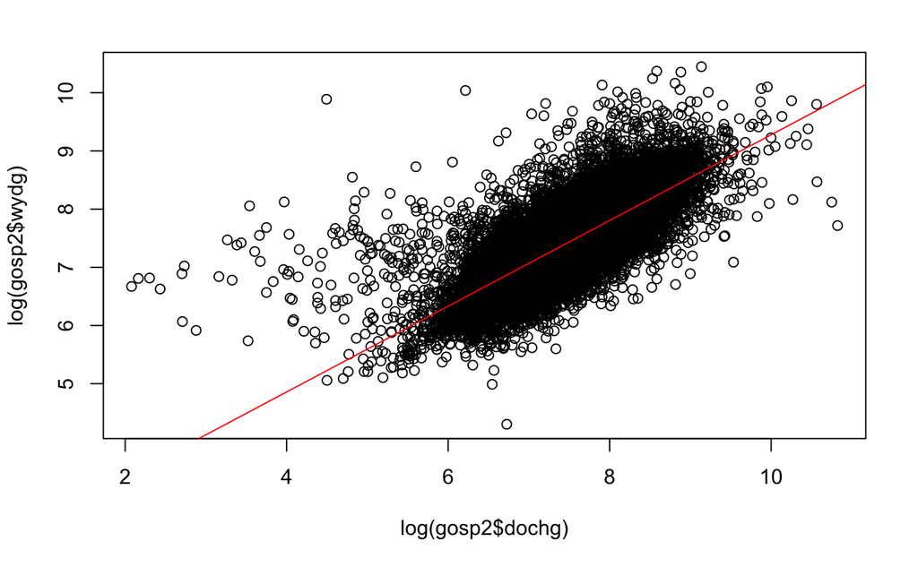

```r
m2 <- lm(log(wydg) ~ log(dochg), gosp2)
plot(log(gosp2$dochg), log(gosp2$wydg))
abline(coef(m2), col = "red")
```

$$\log(y) = \beta_0 + \beta_1\log(x_1)$$

$$\log(y) = \log(b_0) + \log(x_1)^{\beta_1}$$

$$\log(y) = \log(b_0 \times x_1^{\beta_1})$$

$$y = b_0 x_1^{\beta_1}$$

$$y = e^{\beta_0 + \beta_1x_1}$$

$$log(y) = \beta_0 + \beta_1x_1$$

[figure not shown]

```r
summary(model_log_log)
```

```
Call:
lm(formula = log(wydg) ~ log(dochg), data = gosp2)

Residuals:
    Min      1Q  Median      3Q     Max
-2.5635 -0.2148 -0.0180  0.1843  4.6664

Coefficients:
            Estimate Std. Error t value Pr(>|t|)
(Intercept) 1.910564   0.025082   76.17   <2e-16 ***
log(dochg)  0.736770   0.003342  220.47   <2e-16 ***
---
Signif. codes:  0 ‘***’ 0.001 ‘**’ 0.01 ‘*’ 0.05 ‘.’ 0.1 ‘ ’ 1

Residual standard error: 0.377 on 32289 degrees of freedom
Multiple R-squared:  0.6008,    Adjusted R-squared:  0.6008
F-statistic: 4.86e+04 on 1 and 32289 DF,  p-value: < 2.2e-16
```

Jeżeli dochód wzrośnie o 1% to wydatki wzrosną o 0.74%